# Machine Learning Practice

## 对蘑菇进行聚类分析

在本项目中，将在蘑菇属性数据集上尝试运用机器学习模型Kmeans，依据数据的特征构建蘑菇分群。

尝试使用不断探索的方式来分析这份数据并建立机器学习模型。

该项目的结构如下：

- 初探：使用最简单的方式处理数据，看看模型的效果会是如何的。
- 进一步探索：对数据进行降维处理，看看模型的效果会不会被大幅削弱。
- 展示：在这一部分将聚类的效果以非常直观的方式展示出来，对聚类算法有更进一步理解。

## 1. 加载数据

```python
# 导入常用库
import numpy as np
import pandas as pd
import matplotlib.pyplot as plt
import warnings

warnings.filterwarnings('ignore')
%matplotlib inline
```

```python
# Load data
path = '../data/mushrooms.csv'
data = pd.read_csv(path)
```

```python
# Check column names
data.columns.values
```

```
array(['cap-shape', 'cap-surface', 'cap-color', 'bruises', 'odor',
       'gill-attachment', 'gill-spacing', 'gill-size', 'gill-color',
       'stalk-shape', 'stalk-root', 'stalk-surface-above-ring',
       'stalk-surface-below-ring', 'stalk-color-above-ring',
       'stalk-color-below-ring', 'veil-type', 'veil-color', 'ring-number',
       'ring-type', 'spore-print-color', 'population', 'habitat'],
      dtype=object)
```

```python
# Check the shape of the data
print('数据行数：{}，数据列数：{}'.format(data.shape[0], data.shape[1]))
```

```
数据行数：8124，数据列数：22
```

```python
data.head()
```

|  | cap-shape | cap-surface | cap-color | bruises | odor | gill-attachment | gill-spacing | gill-size | gill-color | stalk-shape | ... | stalk-surface-below-ring | stalk-color-above-ring | stalk-color-below-ring | veil-type | veil-color | ring-number | ring-type | spore-print-color | population | habitat |
| --- | --- | --- | --- | --- | --- | --- | --- | --- | --- | --- | --- | --- | --- | --- | --- | --- | --- | --- | --- | --- | --- |
| 0 | x | s | n | t | p | f | c | n | k | e | ... | s | w | w | p | w | o | p | k | s | u |
| 1 | x | s | y | t | a | f | c | b | k | e | ... | s | w | w | p | w | o | p | n | n | g |
| 2 | b | s | w | t | l | f | c | b | n | e | ... | s | w | w | p | w | o | p | n | n | m |
| 3 | x | y | w | t | p | f | c | n | n | e | ... | s | w | w | p | w | o | p | k | s | u |
| 4 | x | s | g | f | n | f | w | b | k | t | ... | s | w | w | p | w | o | e | n | a | g |

5 rows × 22 columns

### 观察

从蘑菇数据样本中，可以看到数据的一些特征：

1. cap-shape: 帽型，铃形=b，锥形=c，凸=x，平面=f，旋钮=k，下陷=s
2. cap-surface: 帽面，纤维=f，沟槽=g，鳞=y，光滑=s
3. cap-color: 帽色，褐色=n，黄色=b，肉桂=c，灰色=g，绿色=r，粉红色=p，紫色=u，红色=e，白色=w，黄色=y
4. bruises: 瘀伤，瘀伤=t，不=f
5. odor: 气味，杏仁=a，茴香=1，杂酚油=c，鱼=y，臭味=f，霉变=m，无一=n，辛辣=p，辛辣=s。
6. gill-attachment: 褶附着，附件=a，下降=d，自由=f，缺口=n
7. gill-spacing: 褶间距，密=c，挤=w，远=d
8. gill-size: 褶大小，宽=b，窄=n
9. gill-color: 褶色，黑色=k，棕色=n，黄色=b，巧克力=h，灰色=g，绿色=r，橙色=o，粉红色=p，紫色=u，红色=e，白色=w，黄色=y。
10. stalk-shape: 柄形，放大=e，变细=t
11. stalk-root: 茎-根，球根=b，棍棒=c，杯=u，相等=e，根状茎=z，根=r，缺失=？
12. stalk-surface-above-ring: 环上茎表面，纤维=f，鳞=y，丝=k，光滑=s
13. stalk-surface-below-ring: 环下茎表面：纤维=f，鳞=y，丝=k，光滑=s
14. stalk-color-above-ring: 环上茎色：褐色=n，BUff=b，肉桂=c，灰色=g，橙色=o，粉红色=p，红色=e，白色=w，黄色=y
15. stalk-color-below-ring: 环下茎色：褐色=n，黄色=b，肉桂=c，灰色=g，橙色=o，粉红色=p，红色=e，白色=w，黄色=y
16. veil-type: 覆盖物型，部分=p，通用=u
17. veil-color: 覆盖物颜色，褐色=n，橙色=o，白色=w，黄色=y
18. ring-number: 环数，0=n，1=o，2=t
19. ring-type: 圆环型：cobwebby=c，式样=e，flling=f，大=l，none=n，吊坠=p，护套=s，zone=z。
20. spore-print-color: 孢子印色，黑色=k，棕色=n，黄色=b，巧克力=h，绿色=r，橙色=o，紫色=u，白色=w，黄色=y
21. population: 种群，富足=a，丛集=c，众多=n，分散=s，数=v，孤立=y
22. habitat: 生长环境：草=g，叶=1，草甸=m，小径=p，城市=u，废物=w，森林=d

特征中包含帽型、帽面、帽色等植物学相关的特征，这里并不需要研究植物学之后再对这些数据进行处理，先将这些特征都作为数据的不同维度属性来平等对待。

## 2. 数据探索

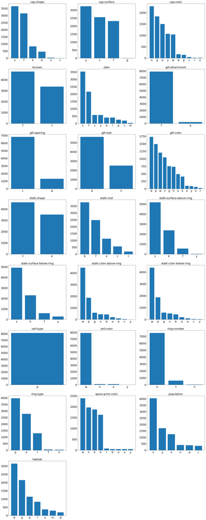

```python
font = {'family' : 'Times New Roman',
'weight' : 'normal',
'size'   : 23,
}

plt.figure(figsize=(30, 80))
# 将要绘制图形的每行由多少个直方图组成
column_per_line = 3
# 属性的总数
columns = len(data.columns)

for i, attr in enumerate(data.columns):
    # 绘制columns个直方图（每个属性一个图），描绘每个属性中不同值的分布情况。
    plt.subplot(int(columns/column_per_line)+1, column_per_line, i+1)
    plt.bar(data[attr].value_counts().index, data[attr].value_counts().values)
    plt.title(attr, fontsize=font['size'], weight=font['weight'])
    plt.xticks(fontsize=font['size'], weight=font['weight'])
    plt.yticks(fontsize=font['size'], weight=font['weight'])

plt.show()
```

从结果中可以看到: veil-type 列属性只有一个值，不具备区分度。

```python
# 从data中将这列没有区分度的属性去除掉
data = data.drop('veil-type', axis=1)
```

### 编码

这个案例中所有数据属性都是非数值类型的，所以需要对属性值进行编码处理。

对仅包含2个可能值的变量使用一个简单的二进制编码，对包含3个或多个可能值的变量进行独热编码。

```python
from sklearn.preprocessing import LabelEncoder
```

```python
# 使用sklearn中的LabelEncoder方法对仅有两个可能值的变量进行编码操作
label_enc = LabelEncoder()

for col in data.columns:
    # 判断col这列是否只有两个值，如果是，使用LabelEncoder对其进行转换并更新到data相应列中
    if len(data[col].unique()) == 2:
        data[col] = label_enc.fit_transform(data[col])
```

```python
# 查看转换之后的数据头部
data.head()
```

|  | cap-shape | cap-surface | cap-color | bruises | odor | gill-attachment | gill-spacing | gill-size | gill-color | stalk-shape | ... | stalk-surface-above-ring | stalk-surface-below-ring | stalk-color-above-ring | stalk-color-below-ring | veil-color | ring-number | ring-type | spore-print-color | population | habitat |
| --- | --- | --- | --- | --- | --- | --- | --- | --- | --- | --- | --- | --- | --- | --- | --- | --- | --- | --- | --- | --- | --- |
| 0 | x | s | n | 1 | p | 1 | 0 | 1 | k | 0 | ... | s | s | w | w | w | o | p | k | s | u |
| 1 | x | s | y | 1 | a | 1 | 0 | 0 | k | 0 | ... | s | s | w | w | w | o | p | n | n | g |
| 2 | b | s | w | 1 | l | 1 | 0 | 0 | n | 0 | ... | s | s | w | w | w | o | p | n | n | m |
| 3 | x | y | w | 1 | p | 1 | 0 | 1 | n | 0 | ... | s | s | w | w | w | o | p | k | s | u |
| 4 | x | s | g | 0 | n | 1 | 1 | 0 | k | 1 | ... | s | s | w | w | w | o | e | n | a | g |

5 rows × 21 columns

对于多值属性，标签编码以及独热编码两个步骤，在Pandas当中，可以直接使用get_dummies一步完成。

```python
# 使用pandas中的get_dummies方法对属性进行独热编码
data = pd.get_dummies(data)
data.head()
```

|  | bruises | gill-attachment | gill-spacing | gill-size | stalk-shape | cap-shape_b | cap-shape_c | cap-shape_f | cap-shape_k | cap-shape_s | ... | population_s | population_v | population_y | habitat_d | habitat_g | habitat_l | habitat_m | habitat_p | habitat_u | habitat_w |
| --- | --- | --- | --- | --- | --- | --- | --- | --- | --- | --- | --- | --- | --- | --- | --- | --- | --- | --- | --- | --- | --- |
| 0 | 1 | 1 | 0 | 1 | 0 | 0 | 0 | 0 | 0 | 0 | ... | 1 | 0 | 0 | 0 | 0 | 0 | 0 | 0 | 1 | 0 |
| 1 | 1 | 1 | 0 | 0 | 0 | 0 | 0 | 0 | 0 | 0 | ... | 0 | 0 | 0 | 0 | 1 | 0 | 0 | 0 | 0 | 0 |
| 2 | 1 | 1 | 0 | 0 | 0 | 1 | 0 | 0 | 0 | 0 | ... | 0 | 0 | 0 | 0 | 0 | 0 | 1 | 0 | 0 | 0 |
| 3 | 1 | 1 | 0 | 1 | 0 | 0 | 0 | 0 | 0 | 0 | ... | 1 | 0 | 0 | 0 | 0 | 0 | 0 | 0 | 1 | 0 |
| 4 | 0 | 1 | 1 | 0 | 1 | 0 | 0 | 0 | 0 | 0 | ... | 0 | 0 | 0 | 0 | 1 | 0 | 0 | 0 | 0 | 0 |

5 rows × 111 columns

## 3. 初步探索

- 用K-means模型来对数据进行拟合。
- 使用轮廓系数对模型进行评价。
- 这里将遍历不同的k值获取模型的最优参数。

```python
import time
from sklearn.metrics import silhouette_score
from sklearn.cluster import KMeans
```

```python
def cluster(X):
    '''
    K-Means聚类执行函数。

    输入
        X：待处理的数据。
    输出
        best_clusters：分数（轮廓系数）最高的分类器
        score：分类器在数据上的轮廓系数

    '''
    print('当前维度为{}'.format(len(X.columns)))
    score = -1
    duration = 0
    start = time.time()

    # 取K值为2到15
    clusters_num = range(2, 15)

    for cluster in clusters_num:
        # 建立kmeans模型，其中聚类数等于cluster
        kmeans = KMeans(n_clusters=cluster, random_state=0)

        # 使用kmeans模型对数据X进行拟合，并用该模型对数据X做聚类预测，存储到test_preds变量中
        test_preds = kmeans.fit_predict(X)

        # 使用silhouette_score计算当前模型预测所得的轮廓系数并赋值到变量test_score中
        test_score = silhouette_score(X, test_preds)

        # 打印计算的轮廓系数
        print("k = {}, component score is {}".format(cluster, test_score))

        #将效果最好的模型中的参数保存起来
        if (score < test_score):
            best_clustersnum = cluster
            score = test_score
            best_clusters = kmeans

    # 统计时间
    end = time.time()
    duration += end - start

    # 打印结果
    print('训练模型耗时: {:.4f}s'.format(duration))
    print('当k为{}的时候，轮廓系数最高，为{:.3f}'.format(best_clustersnum, score))

    return best_clusters, score
```

```python
# 调用cluster函数对data数据做聚类处理
clu, score = cluster(data)
```

```
当前维度为111
k = 2, component score is 0.1578442723522316
k = 3, component score is 0.20502879374121666
k = 4, component score is 0.21043413105310402
k = 5, component score is 0.23339042537543364
k = 6, component score is 0.24850380830199437
k = 7, component score is 0.26123737410383946
k = 8, component score is 0.2626689282545313
k = 9, component score is 0.2701384903730716
k = 10, component score is 0.22076307122994093
k = 11, component score is 0.235273435998553
k = 12, component score is 0.22721043052204629
k = 13, component score is 0.14518531431414008
k = 14, component score is 0.15357768985985357
训练模型耗时: 24.7049s
当k为9的时候，轮廓系数最高，为0.270
```

## 4. 进一步探索

### 降维处理

PCA(principal Component Analysis)，即主成分分析方法，是一种使用最广泛的数据压缩算法。

PCA将原有的数据特征进行坐标转换，生成新的特征坐标。可以指定PCA转换所希望得到的最终特征数来对原始数据进行这样的处理。

PCA算法可以报告出生成的每一个主成分的解释方差比（explained variance ratio）——数据中有多少方差能够用这个单独的维度来解释。

需要特别留意的是，PCA生成的新维度并不是将原有的某些数据维度删除所得，而是由原来数据中的特征转换而来的。

```python
from sklearn.decomposition import PCA
```

```python
# 声明维度为20的PCA对象
pca = PCA(20, random_state=1)

# 对data进行拟合
pca.fit(data)
```

```
PCA(copy=True, iterated_power='auto', n_components=20, random_state=1,
  svd_solver='auto', tol=0.0, whiten=False)
```

```python
# pca.components_中记录了按照解释方差比从大到小排列主成分
components = pd.DataFrame(np.round(pca.components_, 4), columns = [data.keys()])
components.head()
```

|  | bruises | gill-attachment | gill-spacing | gill-size | stalk-shape | cap-shape_b | cap-shape_c | cap-shape_f | cap-shape_k | cap-shape_s | ... | population_s | population_v | population_y | habitat_d | habitat_g | habitat_l | habitat_m | habitat_p | habitat_u | habitat_w |
| --- | --- | --- | --- | --- | --- | --- | --- | --- | --- | --- | --- | --- | --- | --- | --- | --- | --- | --- | --- | --- | --- |
| 0 | -0.2784 | 0.0042 | -0.0643 | 0.1625 | -0.0125 | -0.0329 | -0.0001 | 0.0081 | 0.0698 | -0.0024 | ... | -0.0875 | 0.1746 | -0.0327 | -0.0649 | -0.0601 | 0.0666 | -0.0289 | 0.1144 | -0.0238 | -0.0032 |
| 1 | 0.0434 | 0.0100 | -0.0625 | -0.2370 | -0.1778 | -0.0122 | -0.0002 | 0.0573 | -0.0913 | -0.0008 | ... | -0.0333 | -0.0897 | 0.1774 | 0.0840 | 0.0200 | -0.0892 | -0.0045 | 0.0108 | -0.0037 | -0.0174 |
| 2 | -0.1767 | 0.0039 | 0.2146 | -0.0814 | -0.2222 | 0.0480 | 0.0002 | -0.0565 | -0.0168 | 0.0017 | ... | 0.1832 | -0.2227 | -0.0939 | -0.3430 | 0.3249 | -0.0314 | 0.0232 | -0.0003 | 0.0224 | 0.0041 |
| 3 | -0.1859 | 0.0222 | 0.2356 | -0.0661 | 0.3648 | -0.1056 | -0.0004 | 0.2122 | -0.0297 | 0.0014 | ... | -0.0305 | -0.0162 | 0.0469 | 0.1210 | 0.1100 | -0.0236 | -0.0978 | -0.0590 | -0.0280 | -0.0225 |
| 4 | 0.0282 | -0.0659 | -0.0233 | -0.1563 | -0.1662 | 0.0683 | 0.0008 | 0.4925 | 0.0668 | -0.0003 | ... | -0.0463 | -0.1441 | 0.0627 | -0.1272 | 0.0160 | 0.0581 | -0.0007 | 0.0039 | -0.0248 | 0.0746 |

5 rows × 111 columns

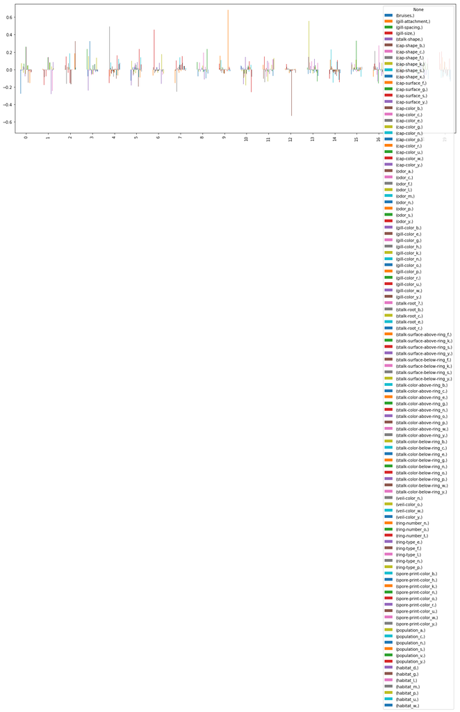

```python
# 使用柱形图绘制每个主成分与原数据特征之间的关系
components.plot.bar(figsize=(20, 6))
plt.show()
```

由于原数据经过独热编码处理之后，维度达到一百多，以上图形看起来并不是那么美观。不过并不影响理解：经过PCA转换之后返回的pca.components_表示按照方差解释比从大到小排列的数据的主成分。从图中看到，每个主成分都与原有的数据特征之间存在一定的关系。

尝试绘制一下20个主成分与前两个维度（bruises、gill-attachment）之间的关系。

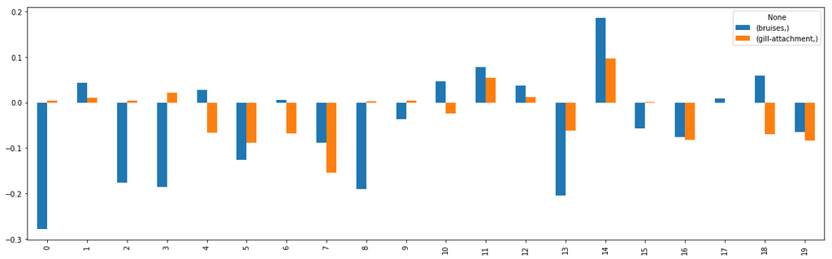

```python
# 使用类似如上图形绘制的方法，绘制20个主成分与前两个维度（bruises、gill-attachment）之间的关系
components_two = pd.DataFrame(np.round(pca.components_, 4), columns = [data.keys()]).iloc[:,:2]
components_two.plot.bar(figsize=(20, 6))

plt.show()
```

从图中可以看出，在所有PCA的主成分中，编号为0的component与bruises的相关性最大，编号为7的component于gill-attachment相关性最大。

每个原特征与主成分的相关性具有正和负两个不同的方向，相关性的绝对值越大，表示原属性与主成分之间的关系越大。

> 参考 https://onlinecourses.science.psu.edu/stat505/node/54/

接下来，计算一下pca中各主成分的方差解释比，以及pca转化之后所有的主成分所能解释的原数据的方差解释比之和。

```python
# 取出pca转换之后各主成分的方差解释比，存在变量var_ratio中
# var_ratio中的元素从大到小排列，分别表示排名最靠前一直到最靠后的方差解释比值各是多少。
var_ratio = pca.explained_variance_ratio_
```

```python
# 查看pca各component的方差解释比
print(var_ratio)
```

```
[0.1619248  0.1372911  0.09241893 0.05522428 0.04015056 0.03829421
 0.03330126 0.02881923 0.02336357 0.02235065 0.02210005 0.01945634
 0.01931097 0.01704539 0.01623854 0.01593473 0.0156207  0.01508337
 0.01339106 0.01211213]
```

```python
# 查看所有方差解释比之和
print(sum(var_ratio))
```

```
0.7994318680226992
```

探索下当选取最少的前多少个主成分时，方差解释比就可以达到70%以上。

```python
# 逐个计算var_ratio中的各元素之和，当至少取前多少个元素时，和大于0.7
count = 0
for k,v in enumerate(var_ratio):
    count += v
    if count > 0.7:
        print('至少取前{}个元素，方差解释比就可以达到70%以上。'.format(k+1))
        break
```

```
至少取前14个元素，方差解释比就可以达到70%以上。
```

按照这个成分数量定义，重新做下PCA转换：

```python
# 重新定义PCA变量pca，主成分数量定义为上面计算的使得解释方差比之和大于0.7的最少特征数。
pca_14= PCA(14, random_state=1)

# 使用pca对数据data进行拟合
pca_14.fit(data)
```

```
PCA(copy=True, iterated_power='auto', n_components=14, random_state=1,
  svd_solver='auto', tol=0.0, whiten=False)
```

查看降维之后模型的效果

```python
# 使用pca对data进行转换并重新做聚类计算
data_pca = pca_14.transform(data)
clu, score = cluster(pd.DataFrame(data_pca))
```

```
当前维度为14
k = 2, component score is 0.22493115487962445
k = 3, component score is 0.29967979296686886
k = 4, component score is 0.314813796266234
k = 5, component score is 0.34525669892377653
k = 6, component score is 0.3697506263663469
k = 7, component score is 0.36255483606104133
k = 8, component score is 0.3785705823373959
k = 9, component score is 0.3495395305213909
k = 10, component score is 0.3549161446385311
k = 11, component score is 0.3553165690175481
k = 12, component score is 0.2473947207671228
k = 13, component score is 0.2595511566228526
k = 14, component score is 0.2598300502645706
训练模型耗时: 17.9199s
当k为8的时候，轮廓系数最高，为0.379
```

**对比可以发现，在降维后，由于维度变小节省了计算时间，但是模型的分数（轮廓系数）并没有受到不好的影响。**

## 5. 聚类效果绘制

现在将聚类的效果通过散点图的形式展示出来，其中，点的颜色表明它属于的簇，数字代表该簇的簇内中心点，这些中心（或者叫平均点）并不是数据中真实存在的点，但是是所有预测在这个簇中的数据点的平均。

为了方便观察，只挑选前两个主成分作为坐标轴，绘制二维的散点图。

```python
import visuals as vs
```

```python
# 使用刚才最优化模型对data_pca数据进行预测，结果存到变量preds中
preds = clu.predict(data_pca)
```

```python
# 从聚类模型cluster中获取各聚类中心点，结果存到变量centers中
centers = clu.cluster_centers_
```

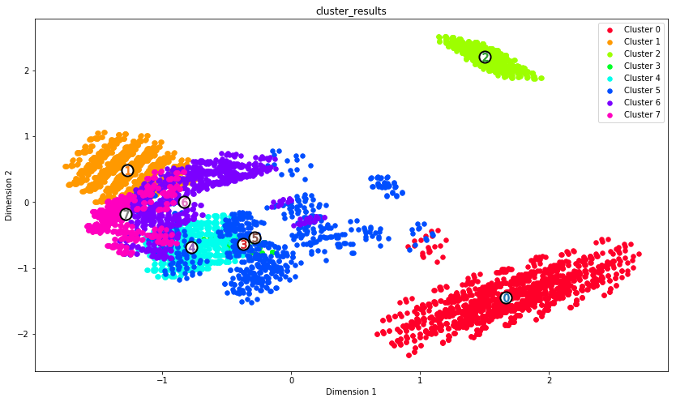

```python
# 绘制散点图
vs.cluster_results(data_pca,preds,centers)
```

在这个案例中，一开始所处理的数据文件其实少掉了一个列属性，完整的数据，放在文件../data/mushrooms_o.csv中

```python
# 加载并查看mushrooms_o.csv中的数据
data_full = pd.read_csv('../data/mushrooms_o.csv')
data_full.head()
```

|  | class | cap-shape | cap-surface | cap-color | bruises | odor | gill-attachment | gill-spacing | gill-size | gill-color | ... | stalk-surface-below-ring | stalk-color-above-ring | stalk-color-below-ring | veil-type | veil-color | ring-number | ring-type | spore-print-color | population | habitat |
| --- | --- | --- | --- | --- | --- | --- | --- | --- | --- | --- | --- | --- | --- | --- | --- | --- | --- | --- | --- | --- | --- |
| 0 | p | x | s | n | t | p | f | c | n | k | ... | s | w | w | p | w | o | p | k | s | u |
| 1 | e | x | s | y | t | a | f | c | b | k | ... | s | w | w | p | w | o | p | n | n | g |
| 2 | e | b | s | w | t | l | f | c | b | n | ... | s | w | w | p | w | o | p | n | n | m |
| 3 | p | x | y | w | t | p | f | c | n | n | ... | s | w | w | p | w | o | p | k | s | u |
| 4 | e | x | s | g | f | n | f | w | b | k | ... | s | w | w | p | w | o | e | n | a | g |

5 rows × 23 columns

这份数据中的class这一列，表示了蘑菇所属的分类，p表示有毒、e表示可以食用。

```python
from sklearn.preprocessing import LabelEncoder
```

```python
# 将class这列从data_full中提取出来，并用LableEncoder做编码转换，转码之后结果存在变量class_label中
label_enc = LabelEncoder()
class_label = label_enc.fit_transform(data_full['class'])
```

```python
type(class_label)
```

```
numpy.ndarray
```

```python
# 查看class_label的前3个元素
class_label[:3]
```

```
array([1, 0, 0])
```

通过LabelEncoder编码之后，p和e所对应的编码分别是1和0

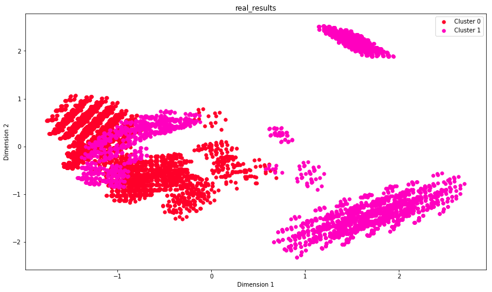

```python
# 绘制原始数据在pca前两个主成分坐标系中的分类图
vs.real_results(data_pca, class_label)
```

虽然在建立KMeans模型之初并不知道数据中存在分类，但通过聚类之后，会发现所聚出的簇跟蘑菇是否有毒的分类存在有趣的相关性。

在原始数据的有毒蘑菇中，从图中可以大致对应到通过KMeans聚出来的cluster 0, 2, 6, 7

数据通过聚类算法处理获取的聚类特征，在实际项目中可以作为原有特征的一个附加特征列加入到数据中。

这样之后，将重新组合出来的数据作为监督学习（比如分类）输入数据，往往可以获取到比只使用原有特征进行计算更好的结果。

## 6. 增大保留方差解释比

在设置PCA主成分数量的时候，在以上操作中通过循环尝试选择了能保留70%多方差解释比的主成分数量，在最终的聚类与原始数据的分类分布上还存在一些差异。

在构建PCA对象的时候，传入的n_components参数值如果为一个小于1的小数，将表示在PCA转换中，保留多大比例的方差解释比。

```python
# 构建保留百分之九十九方差解释比的PCA并对data进行拟合转换
pca_99 = PCA(n_components = 0.99, random_state=1)

# 使用pca对数据data进行拟合
pca_99.fit(data)
```

```
PCA(copy=True, iterated_power='auto', n_components=0.99, random_state=1,
  svd_solver='auto', tol=0.0, whiten=False)
```

```python
# 使用pca对data进行转换并重新做聚类计算
data_pca_99 = pca.transform(data)
clu, score = cluster(pd.DataFrame(data_pca_99))
```

```
当前维度为20
k = 2, component score is 0.19884589145495513
k = 3, component score is 0.26349037438623696
k = 4, component score is 0.2724221488706875
k = 5, component score is 0.2995073778813427
k = 6, component score is 0.31940626479916234
k = 7, component score is 0.31910646406849036
k = 8, component score is 0.32184912506143304
k = 9, component score is 0.2958202694685114
k = 10, component score is 0.24159011934181762
k = 11, component score is 0.29222476548416965
k = 12, component score is 0.26149513648811684
k = 13, component score is 0.2597861828646237
k = 14, component score is 0.21843912542164523
训练模型耗时: 18.1833s
当k为8的时候，轮廓系数最高，为0.322
```

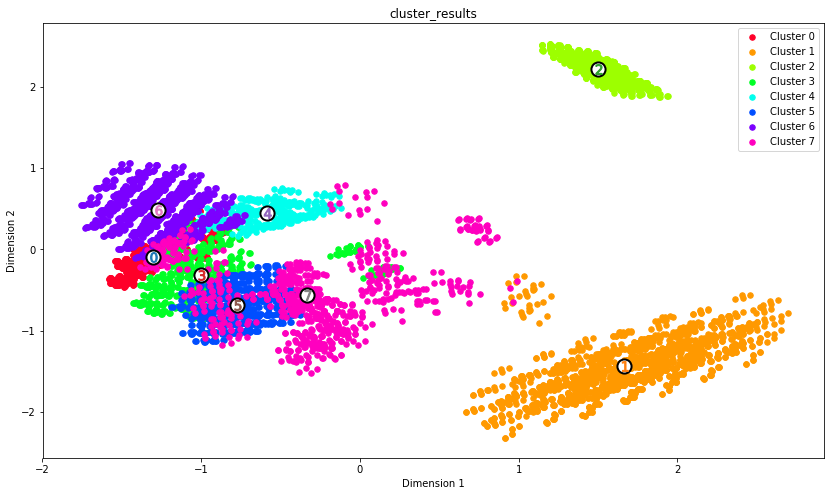

```python
# 使用刚才最优化模型对data_pca数据进行预测，结果存到变量preds中
preds = clu.predict(data_pca_99)

# 从聚类模型cluster中获取各聚类中心点，结果存到变量centers中
centers = clu.cluster_centers_

# 绘制散点图
vs.cluster_results(data_pca_99,preds,centers)
```

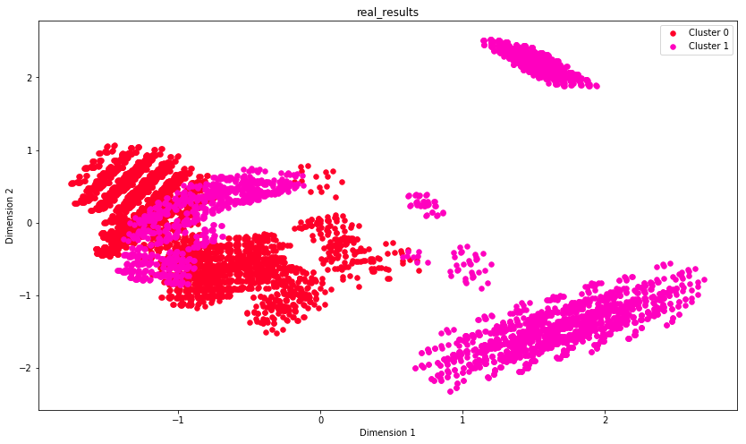

```python
# 绘制原始数据在pca前两个主成分坐标系中的分类图
vs.real_results(data_pca_99,class_label)
```

对比发现，有毒的蘑菇主要是 cluster 0,1,2,3,4